# IDeA Tutorial: Body_fat

Jose Tamez

2023-09-18

# 1 Effect of UPSTM-Based Decorrelation on Feature Discovery

### 1.0.1 Loading the libraries

```r
library("FRESA.CAD")
library(readxl)
library(umap)

op <- par(no.readonly = TRUE)
pander::panderOptions('digits', 3)
pander::panderOptions('table.split.table', 400)
pander::panderOptions('keep.trailing.zeros',TRUE)
```

# 2 IDeA Tutorial

## 2.1 Material and Methods

Data Source https://www.kaggle.com/datasets/fedesoriano/body-fat-prediction-dataset

“Source The data were generously supplied by Dr. A. Garth Fisher who gave permission to freely distribute the data and use for non-commercial purposes.

Roger W. Johnson Department of Mathematics & Computer Science South Dakota School of Mines & Technology 501 East St. Joseph Street Rapid City, SD 57701

email address: rwjohnso@silver.sdsmt.edu web address: http://silver.sdsmt.edu/~rwjohnso”

## 2.2 Loading the Data

```r
body_fat <- read.csv("~/GitHub/LatentBiomarkers/Data/BodyFat/BodyFat.csv", header=TRUE)

### Removing density as estimator
body_fat$Density <- NULL

body_fat$BMI <- 10000*body_fat$Weight*0.453592/((body_fat$Height*2.54)^2)
## Removing subjects with data errors
body_fat <- body_fat[body_fat$BMI<=50,]
```

## 2.3 IDeA unsupervised processing

```r
body_fat_Decorrelated <- IDeA(body_fat,thr=0.2,verbose=TRUE)
```

Included: 15 , Uni p: 0.03901567 , Uncorrelated Base: 1 , Outcome-Driven Size: 0 , Base Size: 1

1 <R=0.944,thr=0.900,N= 5>, Top: 2( 1 )1 : 2 Fa= 2 : 0.900,<|>Tot Used: 5 , Added: 3 , Zero Std: 0 , Max Cor: 0.888

2 <R=0.888,thr=0.750,N= 7>, Top: 2( 5 )1 : 2 Fa= 2 : 0.750,<|>Tot Used: 9 , Added: 5 , Zero Std: 0 , Max Cor: 0.735

3 <R=0.735,thr=0.600,N= 5>, Top: 1( 1 )1 : 1 Fa= 3 : 0.600,<|>Tot Used: 10 , Added: 1 , Zero Std: 0 , Max Cor: 0.655

4 <R=0.655,thr=0.600,N= 5>, Top: 1( 2 )1 : 1 Fa= 3 : 0.600,<|>Tot Used: 12 , Added: 2 , Zero Std: 0 , Max Cor: 0.687

5 <R=0.687,thr=0.600,N= 5>, Top: 1( 1 )1 : 1 Fa= 4 : 0.600,<|>Tot Used: 12 , Added: 1 , Zero Std: 0 , Max Cor: 0.771

6 <R=0.771,thr=0.750,N= 2>, Top: 1( 1 )1 : 1 Fa= 4 : 0.750,<|>Tot Used: 12 , Added: 1 , Zero Std: 0 , Max Cor: 0.587

7 <R=0.587,thr=0.450,N= 8>, Top: 1( 3 )1 : 1 Fa= 4 : 0.450,<|>Tot Used: 12 , Added: 3 , Zero Std: 0 , Max Cor: 0.570

8 <R=0.570,thr=0.450,N= 8>, Top: 1( 3 )1 : 1 Fa= 4 : 0.450,<|>Tot Used: 14 , Added: 3 , Zero Std: 0 , Max Cor: 0.509

9 <R=0.509,thr=0.450,N= 8>, Top: 1( 1 )1 : 1 Fa= 4 : 0.450,<|>Tot Used: 14 , Added: 1 , Zero Std: 0 , Max Cor: 0.747

10 <R=0.747,thr=0.600,N= 2>, Top: 1( 1 )1 : 1 Fa= 4 : 0.600,<|>Tot Used: 14 , Added: 1 , Zero Std: 0 , Max Cor: 0.488

11 <R=0.488,thr=0.450,N= 2>, Top: 1( 1 )1 : 1 Fa= 4 : 0.450,<|>Tot Used: 14 , Added: 1 , Zero Std: 0 , Max Cor: 0.449

12 <R=0.449,thr=0.200,N= 15>, Top: 33=2 : 3 Fa= 4 : 0.294,<|>Tot Used: 15 , Added: 5 , Zero Std: 0 , Max Cor: 0.449

13 <R=0.449,thr=0.200,N= 15>, Top: 4( 1 )1 : 4 Fa= 4 : 0.200,<|>Tot Used: 15 , Added: 5 , Zero Std: 0 , Max Cor: 0.426

14 <R=0.426,thr=0.200,N= 15>, Top: 2( 1 )1 : 2 Fa= 4 : 0.200,<|>Tot Used: 15 , Added: 2 , Zero Std: 0 , Max Cor: 0.443

15 <R=0.443,thr=0.200,N= 15>, Top: 1( 4 )1 : 1 Fa= 5 : 0.200,<|>Tot Used: 15 , Added: 4 , Zero Std: 0 , Max Cor: 0.396

16 <R=0.396,thr=0.200,N= 15>, Top: 2( 3 )1 : 2 Fa= 6 : 0.200,<|>Tot Used: 15 , Added: 4 , Zero Std: 0 , Max Cor: 0.343

17 <R=0.343,thr=0.200,N= 15>, Top: 3( 1 )1 : 3 Fa= 7 : 0.200,<|>Tot Used: 15 , Added: 4 , Zero Std: 0 , Max Cor: 0.318

18 <R=0.318,thr=0.200,N= 15>, Top: 2( 1 )1 : 2 Fa= 9 : 0.200,<|>Tot Used: 15 , Added: 3 , Zero Std: 0 , Max Cor: 0.231

19 <R=0.231,thr=0.200,N= 15>, Top: 1( 1 )1 : 1 Fa= 10 : 0.200,<|>Tot Used: 15 , Added: 1 , Zero Std: 0 , Max Cor: 0.200

20 <R=0.200,thr=0.200,N= 0>

[ 20 ], 0.1996834 Decor Dimension: 15 Nused: 15 . Cor to Base: 14 , ABase: 1 , Outcome Base: 0

### 2.3.1 IDeA Transformation

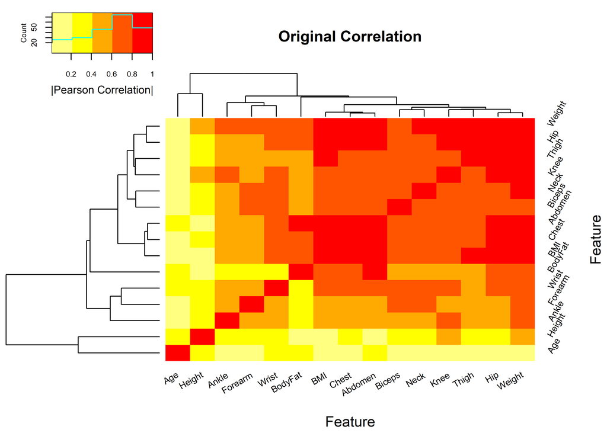

```r
  par(cex=0.6,cex.main=0.85,cex.axis=0.7)
  cormat <- cor(body_fat,method="pearson")
  gplots::heatmap.2(abs(cormat),
                    trace = "none",
                    mar = c(5,5),
                    col=rev(heat.colors(5)),
                    main = "Original Correlation",
                    cexRow = 0.75,
                    cexCol = 0.75,
                     srtCol=30,
                     srtRow=60,
                    key.title=NA,
                    key.xlab="|Pearson Correlation|",
                    xlab="Feature", ylab="Feature")
```

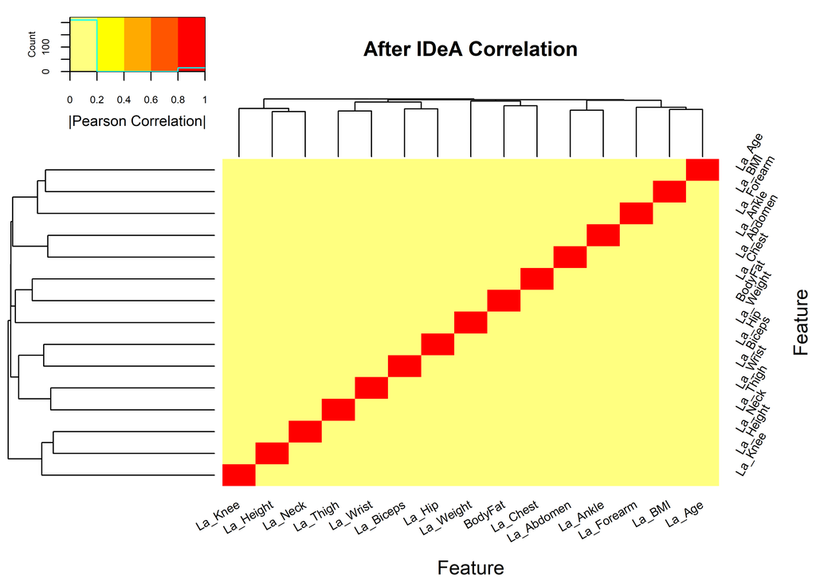

```r
  cormat <- cor(body_fat_Decorrelated,method="pearson")
  gplots::heatmap.2(abs(cormat),
                    trace = "none",
                    mar = c(5,5),
                    col=rev(heat.colors(5)),
                    main = "After IDeA Correlation",
                    cexRow = 0.75,
                    cexCol = 0.75,
                     srtCol=30,
                     srtRow=60,
                    key.title=NA,
                    key.xlab="|Pearson Correlation|",
                    xlab="Feature", ylab="Feature")
```

### 2.3.2 Exploring transformation

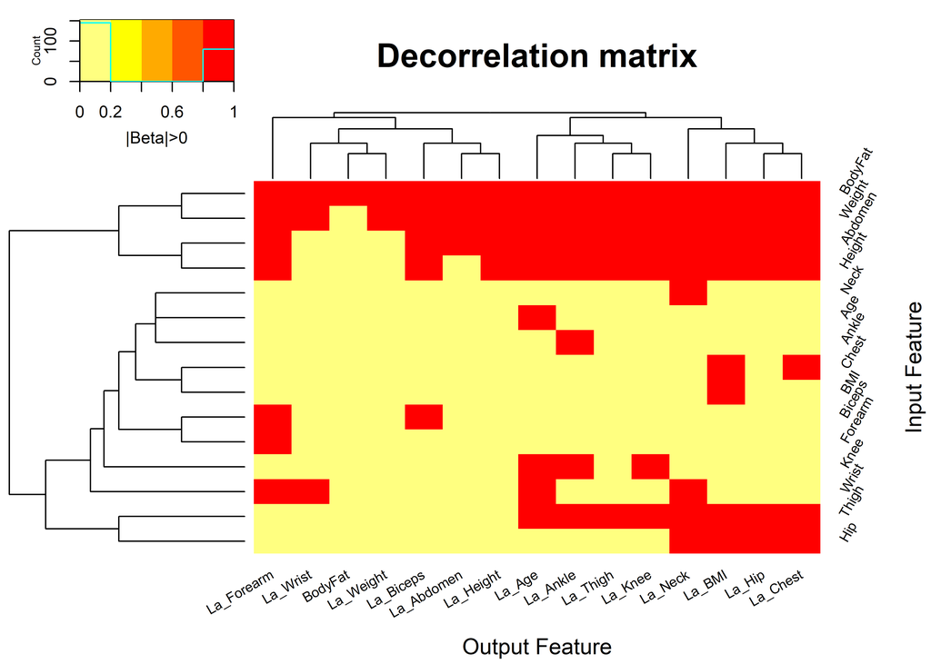

```r
  UPSTM <- attr(body_fat_Decorrelated,"UPSTM")

  gplots::heatmap.2(1.0*(abs(UPSTM)>0),
                    trace = "none",
                    mar = c(5,5),
                    col=rev(heat.colors(5)),
                    main = "Decorrelation matrix",
                    cexRow = 0.75,
                    cexCol = 0.75,
                   srtCol=30,
                   srtRow=60,
                    key.title=NA,
                    key.xlab="|Beta|>0",
                    xlab="Output Feature", ylab="Input Feature")
```

### 2.3.3 The latent Formulas

```r
# Get a list with the latent formulas' coefficients
LatentFormulas <- getLatentCoefficients(body_fat_Decorrelated)

# A string character with the formulas can be obtained by:
charFormulas <- attr(LatentFormulas,"LatentCharFormulas")
pander::pander(as.matrix(charFormulas))
```

| **La_Age** | - (0.056)BodyFat + Age + (0.297)Weight + (0.753)Height - (1.182)Abdomen + (2.088)Thigh - (1.577)Knee - (6.141)Wrist |
| --- | --- |
| **La_Weight** | - (2.153)BodyFat + Weight |
| **La_Height** | + (7.23e-03)BodyFat - (0.131)Weight + Height + (0.263)Abdomen |
| **La_Neck** | + (3.69e-04)BodyFat - (0.070)Weight + (0.013)Height + Neck - (0.020)Abdomen + (0.146)Hip - (0.058)Thigh - (0.755)Wrist |
| **La_Chest** | - (0.010)BodyFat - (0.299)Weight + (0.631)Height + Chest - (0.337)Abdomen + (0.336)Hip + (0.268)Thigh |
| **La_Abdomen** | - (0.557)BodyFat - (0.229)Weight + Abdomen |
| **La_Hip** | + (0.090)BodyFat - (0.142)Weight + (0.089)Height - (0.136)Abdomen + Hip - (0.395)Thigh |
| **La_Thigh** | + (2.61e-03)BodyFat - (0.202)Weight + (0.361)Height + (0.095)Abdomen + Thigh |
| **La_Knee** | - (3.49e-04)BodyFat - (0.043)Weight - (0.048)Height - (0.013)Abdomen - (0.134)Thigh + Knee |
| **La_Ankle** | + (0.036)BodyFat - (0.032)Weight + (0.011)Height + (2.95e-03)Abdomen + (0.031)Thigh - (0.233)Knee + Ankle |
| **La_Biceps** | + (1.72e-03)BodyFat - (0.114)Weight + (0.238)Height + (0.063)Abdomen + Biceps |
| **La_Forearm** | - (0.056)BodyFat - (0.022)Weight - (0.064)Height + (0.082)Abdomen - (0.269)Biceps + Forearm - (0.580)Wrist |
| **La_Wrist** | + (0.017)BodyFat - (0.026)Weight + Wrist |
| **La_BMI** | - (0.013)BodyFat - (0.128)Weight + (0.686)Height - (0.023)Chest - (3.14e-03)Abdomen - (7.70e-03)Hip - (6.12e-03)Thigh + BMI |

### 2.3.4 Latent Formulas Interpretation

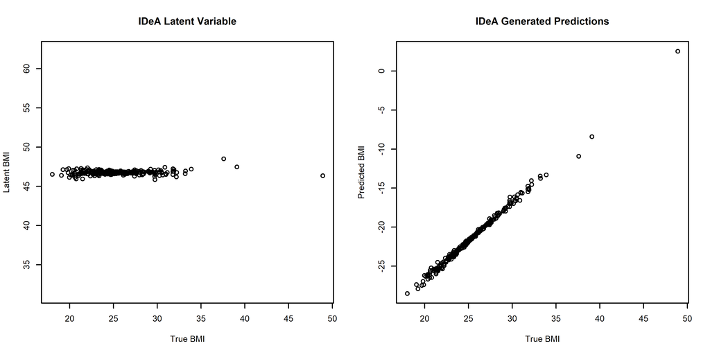

```r
par(mfrow=c(1,2),cex=0.5)

mvbmi <- mean(body_fat_Decorrelated$La_BMI)
range <- max(body_fat$BMI)-min(body_fat$BMI)
ylim <- c(mvbmi-range/2,mvbmi+range/2)
plot(body_fat$BMI,body_fat_Decorrelated$La_BMI,
     ylim=ylim,
     ylab="Latent BMI",
     xlab="True BMI",
     main="IDeA Latent Variable")
BMIformula <- LatentFormulas[["La_BMI"]]
noBMInames <- names(BMIformula)[names(BMIformula) != "BMI"]
predBMI <- -(as.matrix(body_fat[,noBMInames]) %*% BMIformula[noBMInames])
plot(body_fat$BMI,predBMI,xlab="True BMI",ylab="Predicted BMI",main="IDeA Generated Predictions")
```

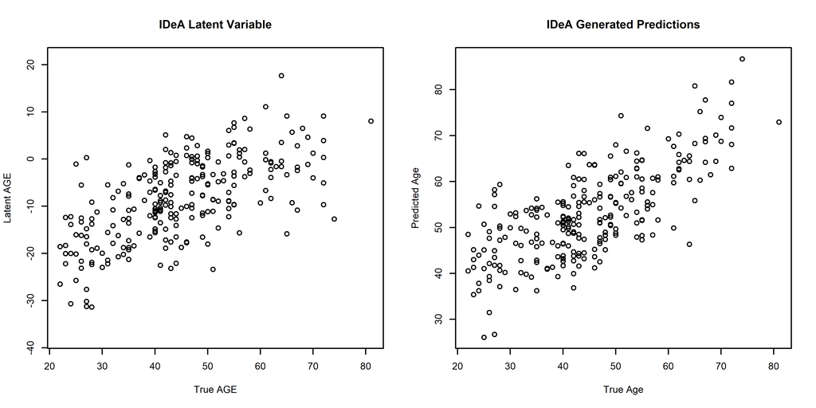

```r
mvage <- mean(body_fat_Decorrelated$La_Age)
range <- max(body_fat$Age)-min(body_fat$Age)
ylim <- c(mvage-range/2,mvage+range/2)


plot(body_fat$Age,body_fat_Decorrelated$La_Age,
     ylim=ylim,
     ylab="Latent AGE",
     xlab="True AGE",
     main="IDeA Latent Variable")
Ageformula <- LatentFormulas[["La_Age"]]
noAgenames <- names(Ageformula)[names(Ageformula) != "Age"]
predAge <- -(as.matrix(body_fat[,noAgenames]) %*% Ageformula[noAgenames])
plot(body_fat$Age,predAge,xlab="True Age",ylab="Predicted Age",main="IDeA Generated Predictions")
```

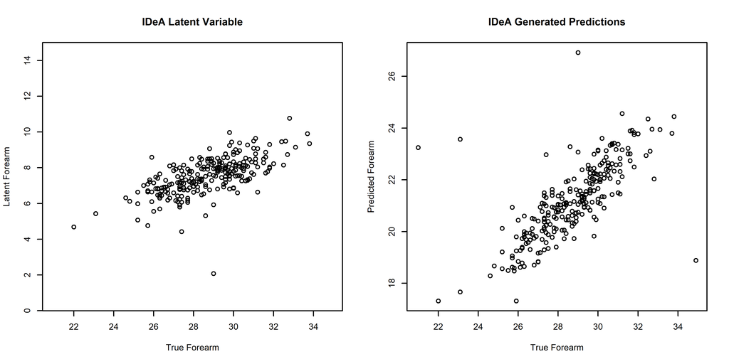

```r
mvage <- mean(body_fat_Decorrelated$La_Forearm)
range <- max(body_fat$Forearm)-min(body_fat$Forearm)
ylim <- c(mvage-range/2,mvage+range/2)

plot(body_fat$Forearm,body_fat_Decorrelated$La_Forearm,
     ylim=ylim,
     ylab="Latent Forearm",
     xlab="True Forearm",
     main="IDeA Latent Variable")
Forearmformula <- LatentFormulas[["La_Forearm"]]
noForearmnames <- names(Forearmformula)[names(Forearmformula) != "Forearm"]
predForearm <- -(as.matrix(body_fat[,noForearmnames]) %*% Forearmformula[noForearmnames])
plot(body_fat$Forearm,predForearm,xlab="True Forearm",ylab="Predicted Forearm",main="IDeA Generated Predictions")
```

```r
par(op)
```

## 2.4 IDeA for Supervised Learning

### 2.4.1 Splint into Training Tesiting Sets

```r
# 75% for training 25% for testing
set.seed(1)
trainsamples <- sample(nrow(body_fat),3*nrow(body_fat)/4)

trainingset <- body_fat[trainsamples,]
testingset <- body_fat[-trainsamples,]
```

## 2.5 Data decorrelation of the train set and prediction of the test set

```r
body_fat_Decorrelated_train <- IDeA(trainingset,thr=0.2,Outcome="BodyFat",drivingFeatures="NA")
body_fat_Decorrelated_test <- predictDecorrelate(body_fat_Decorrelated_train,testingset)
```

### 2.5.1 Train a regression model for body fat prediction

```r
modelBodyFat <- LASSO_1SE(BodyFat~.,body_fat_Decorrelated_train)
pander::pander(as.matrix(modelBodyFat$coef))
```

| **(Intercept)** | -80.744 |
| --- | --- |
| **Age** | 0.151 |
| **Weight** | 0.154 |
| **La_Height** | -0.611 |
| **La_Chest** | 0.206 |
| **La_Abdomen** | 0.682 |
| **La_Hip** | 0.232 |
| **La_Thigh** | 0.116 |
| **La_Wrist** | -2.746 |
| **La_BMI** | 2.044 |

### 2.5.2 The model coefficients in the observed space

```r
# Get the coefficients in the observed space
observedCoef <- getObservedCoef(body_fat_Decorrelated_train,modelBodyFat)
pander::pander(as.matrix(observedCoef$coefficients))
```

| **(Intercept)** | -80.7443 |
| --- | --- |
| **Age** | 0.0733 |
| **Weight** | -0.1993 |
| **Height** | 1.3361 |
| **Chest** | -0.1694 |
| **Abdomen** | 0.6394 |
| **Hip** | -0.3347 |
| **Thigh** | 0.1156 |
| **Forearm** | 0.2073 |
| **Wrist** | -1.9353 |
| **BMI** | 2.0442 |

### 2.5.3 Predict using the transformed data set

```r
predicBodyFat <- predict(modelBodyFat,body_fat_Decorrelated_test)
rmetrics <- predictionStats_regression(cbind(testingset$BodyFat,predicBodyFat),"Body Fat")
```

Body Fat

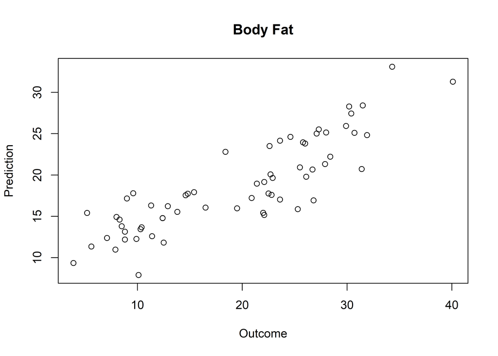

```r
pander::pander(rmetrics)
```

- **corci**:

  | cor |  |  |
  | --- | --- | --- |
  | 0.863 | 0.782 | 0.915 |

- **biasci**: *-0.714*, *-1.952* and *0.524*
- **RMSEci**: *4.97*, *4.23* and *6.02*
- **spearmanci**:

  | 50% | 2.5% | 97.5% |
  | --- | --- | --- |
  | 0.869 | 0.791 | 0.921 |

- **MAEci**:

  | 50% | 2.5% | 97.5% |
  | --- | --- | --- |
  | 4.25 | 3.67 | 4.91 |

- **pearson**:

  Pearson’s product-moment correlation: `predictions[, 1]` and `predictions[, 2]`

  | Test statistic | df | P value | Alternative hypothesis | cor |
  | --- | --- | --- | --- | --- |
  | 13.3 | 61 | 9.81e-20 * * * | two.sided | 0.863 |

### 2.5.4 Prediction using the observed features

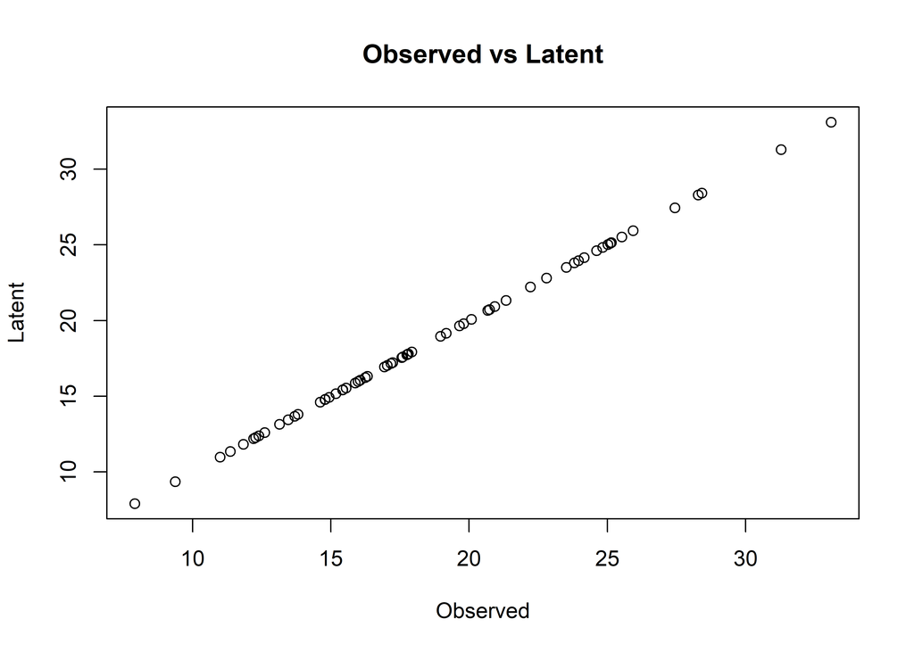

```r
predicBodyFatObst <- model.matrix(formula(observedCoef$formula),testingset) %*% observedCoef$coefficients

plot(predicBodyFatObst,predicBodyFat,xlab="Observed",ylab="Latent",main="Observed vs Latent")
```

### 2.5.5 Comparison to raw model

```r
rawmodelBodyFat <- LASSO_1SE(BodyFat~.,trainingset)
pander::pander(rawmodelBodyFat$coef)
```

| (Intercept) | Age | Height | Abdomen | Wrist |
| --- | --- | --- | --- | --- |
| -12.7 | 0.0439 | -0.121 | 0.611 | -1.02 |

```r
rawpredicBodyFat <- predict(rawmodelBodyFat,testingset)
rmetrics <- predictionStats_regression(cbind(testingset$BodyFat,rawpredicBodyFat),"Body Fat")
```

Body Fat

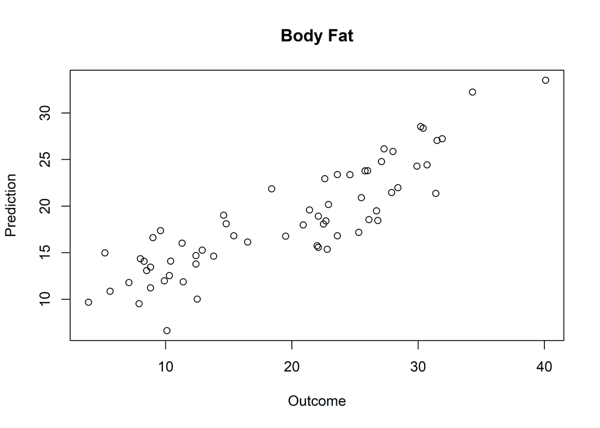

```r
pander::pander(rmetrics)
```

- **corci**:

  | cor |  |  |
  | --- | --- | --- |
  | 0.875 | 0.801 | 0.923 |

- **biasci**: *-0.933*, *-2.113* and *0.247*
- **RMSEci**: *4.78*, *4.07* and *5.79*
- **spearmanci**:

  | 50% | 2.5% | 97.5% |
  | --- | --- | --- |
  | 0.884 | 0.818 | 0.928 |

- **MAEci**:

  | 50% | 2.5% | 97.5% |
  | --- | --- | --- |
  | 4.09 | 3.5 | 4.7 |

- **pearson**:

  Pearson’s product-moment correlation: `predictions[, 1]` and `predictions[, 2]`

  | Test statistic | df | P value | Alternative hypothesis | cor |
  | --- | --- | --- | --- | --- |
  | 14.1 | 61 | 6.88e-21 * * * | two.sided | 0.875 |

### 2.5.6 Comparing the feature significance on the model

```r
par(mfrow=c(2,2),cex=0.5)

rawlm <- lm(BodyFat~.,trainingset[,c("BodyFat",names(rawmodelBodyFat$coef)[-1])])
pander::pander(rawlm,add.significance.stars=TRUE)
```

Fitting linear model: BodyFat ~ .

|  | Estimate | Std. Error | t value | Pr(>\|t\|) |  |
| --- | --- | --- | --- | --- | --- |
| **(Intercept)** | 0.7986 | 9.6573 | 0.0827 | 9.34e-01 |  |
| **Age** | 0.0728 | 0.0286 | 2.5461 | 1.17e-02 | * |
| **Height** | -0.1527 | 0.1491 | -1.0246 | 3.07e-01 |  |
| **Abdomen** | 0.7087 | 0.0384 | 18.4545 | 1.23e-43 | * * * |
| **Wrist** | -2.1962 | 0.4950 | -4.4365 | 1.58e-05 | * * * |

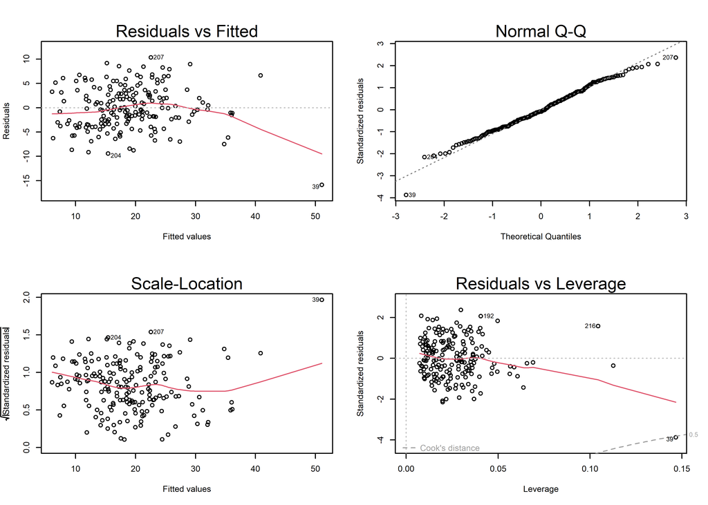

```r
plot(rawlm)
```

```r
par(mfrow=c(2,2),cex=0.5)
Delm <- lm(BodyFat~.,body_fat_Decorrelated_train[,c("BodyFat",names(modelBodyFat$coef)[-1])])
pander::pander(Delm,add.significance.stars=TRUE)
```

Fitting linear model: BodyFat ~ .

|  | Estimate | Std. Error | t value | Pr(>\|t\|) |  |
| --- | --- | --- | --- | --- | --- |
| **(Intercept)** | -179.773 | 57.3629 | -3.13 | 2.02e-03 | * * |
| **Age** | 0.189 | 0.0256 | 7.38 | 5.96e-12 | * * * |
| **Weight** | 0.169 | 0.0100 | 16.89 | 7.98e-39 | * * * |
| **La_Height** | -0.779 | 0.1582 | -4.93 | 1.91e-06 | * * * |
| **La_Chest** | 0.387 | 0.1047 | 3.70 | 2.92e-04 | * * * |
| **La_Abdomen** | 0.834 | 0.0978 | 8.53 | 6.38e-15 | * * * |
| **La_Hip** | 0.454 | 0.1402 | 3.24 | 1.44e-03 | * * |
| **La_Thigh** | 0.368 | 0.1588 | 2.32 | 2.17e-02 | * |
| **La_Wrist** | -3.265 | 0.5648 | -5.78 | 3.27e-08 | * * * |
| **La_BMI** | 3.687 | 1.1723 | 3.14 | 1.95e-03 | * * |

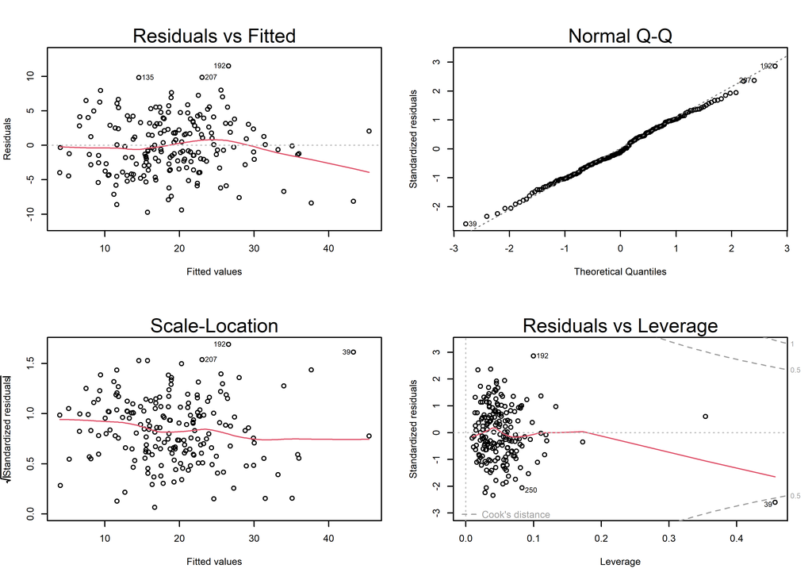

```r
plot(Delm)
```

```r
par(op)
```

## 2.6 Train a regression model for Overweight prediction

### 2.6.1 First remove Height and Weight from training and testing sets

```r
trainingsetBMI <- trainingset[,!(colnames(trainingset) %in% c("Weight","Height"))]
testingsetBMI <- testingset[,!(colnames(trainingset) %in% c("Weight","Height"))]
trainingsetBMI$Overweight <- 1*(trainingsetBMI$BMI>=25)
testingsetBMI$Overweight <- 1*(testingsetBMI$BMI>=25)
trainingsetBMI$BMI <- NULL
testingsetBMI$BMI <- NULL
table(trainingsetBMI$Overweight)
```

```
#>
#>  0  1
#> 91 97
```

```r
table(testingsetBMI$Overweight)
```

```
#>
#>  0  1
#> 34 29
```

```r
BMI_Decorrelated_train <- IDeA(trainingsetBMI,thr=0.2,Outcome="Overweight",drivingFeatures="NA")
BMI_Decorrelated_test <- predictDecorrelate(BMI_Decorrelated_train,testingsetBMI)
```

```r
modelOverweight <- LASSO_1SE(Overweight~.,BMI_Decorrelated_train,family="binomial")
pander::pander(as.matrix(modelOverweight$coef))
```

| **(Intercept)** | -29.9541 |
| --- | --- |
| **BodyFat** | 0.2596 |
| **La_Chest** | 0.0367 |
| **La_Hip** | 0.2848 |

### 2.6.2 The model coefficients in the observed space

```r
# Get the coefficients in the observed space
observedCoef <- getObservedCoef(BMI_Decorrelated_train,modelOverweight)
pander::pander(as.matrix(observedCoef$coefficients))
```

| **(Intercept)** | -29.9541 |
| --- | --- |
| **BodyFat** | 0.0729 |
| **Chest** | 0.1320 |
| **Hip** | 0.1552 |

### 2.6.3 Predict using the transformed data set

```r
predicOverweight <- predict(modelOverweight,BMI_Decorrelated_test)
pr <- predictionStats_binary(cbind(BMI_Decorrelated_test$Overweight,predicOverweight),"Overweight")
```

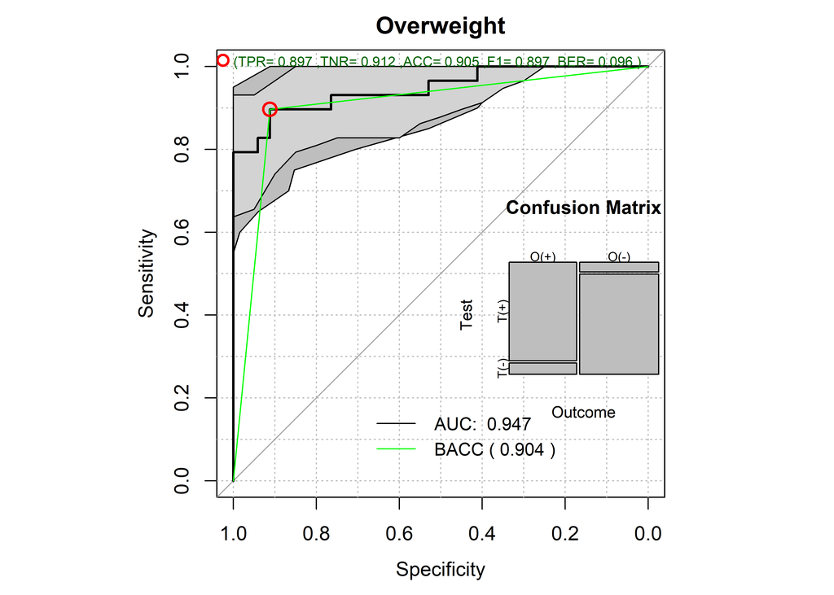

```r
pander::pander(pr$ClassMetrics)
```

- **accci**:

  | 50% | 2.5% | 97.5% |
  | --- | --- | --- |
  | 0.905 | 0.825 | 0.968 |

- **senci**:

  | 50% | 2.5% | 97.5% |
  | --- | --- | --- |
  | 0.907 | 0.826 | 0.97 |

- **aucci**:

  | 50% | 2.5% | 97.5% |
  | --- | --- | --- |
  | 0.907 | 0.826 | 0.97 |

- **berci**:

  | 50% | 2.5% | 97.5% |
  | --- | --- | --- |
  | 0.0926 | 0.0303 | 0.174 |

- **preci**:

  | 50% | 2.5% | 97.5% |
  | --- | --- | --- |
  | 0.907 | 0.826 | 0.968 |

- **F1ci**:

  | 50% | 2.5% | 97.5% |
  | --- | --- | --- |
  | 0.905 | 0.825 | 0.968 |

### 2.6.4 Prediction using the observed features

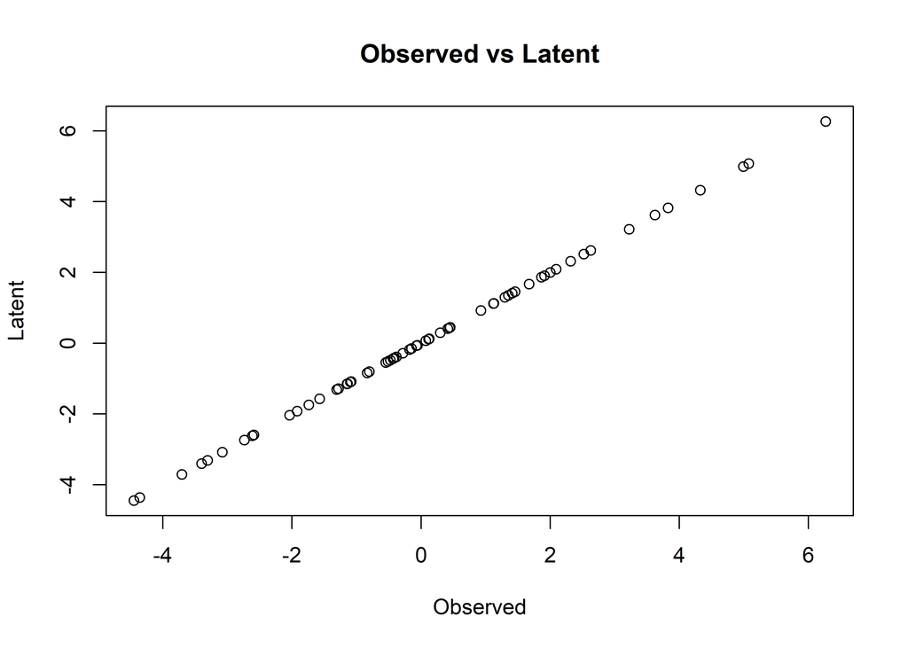

```r
predicOverweightObst <- model.matrix(formula(observedCoef$formula),testingsetBMI) %*% observedCoef$coefficients
#predicOverweightObst <- 1.0/(1.0 + exp(-predicOverweightObst));

plot(predicOverweightObst,predicOverweight,xlab="Observed",ylab="Latent",main="Observed vs Latent")
```

### 2.6.5 Comparison to raw model

```r
rawmodelOverweight <- LASSO_1SE(Overweight~.,trainingsetBMI,family="binomial")
pander::pander(rawmodelOverweight$coef)
```

| (Intercept) | BodyFat | Chest | Abdomen | Thigh | Biceps | Forearm |
| --- | --- | --- | --- | --- | --- | --- |
| -32.4 | 0.0135 | 0.171 | 0.0987 | 0.078 | 0.0221 | 0.0261 |

```r
rawpredicOverweight <- predict(rawmodelOverweight,testingsetBMI)
pr <- predictionStats_binary(cbind(testingsetBMI$Overweight,rawpredicOverweight),"Overweight")
```

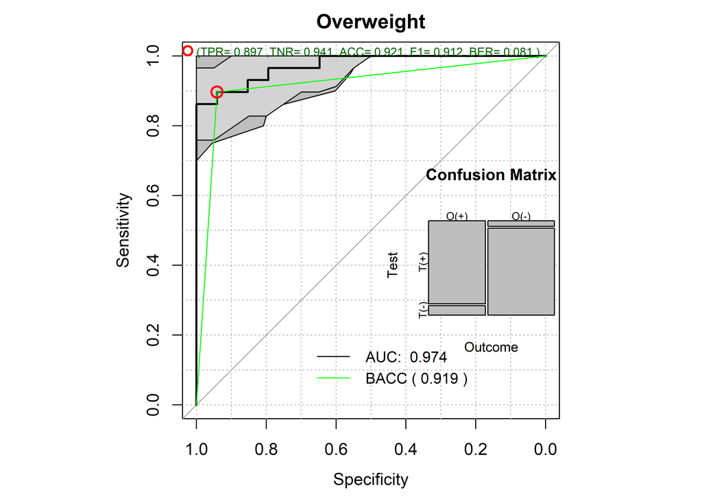

```r
pander::pander(pr$ClassMetrics)
```

- **accci**:

  | 50% | 2.5% | 97.5% |
  | --- | --- | --- |
  | 0.921 | 0.857 | 0.984 |

- **senci**:

  | 50% | 2.5% | 97.5% |
  | --- | --- | --- |
  | 0.92 | 0.847 | 0.984 |

- **aucci**:

  | 50% | 2.5% | 97.5% |
  | --- | --- | --- |
  | 0.92 | 0.847 | 0.984 |

- **berci**:

  | 50% | 2.5% | 97.5% |
  | --- | --- | --- |
  | 0.0801 | 0.0161 | 0.153 |

- **preci**:

  | 50% | 2.5% | 97.5% |
  | --- | --- | --- |
  | 0.921 | 0.848 | 0.984 |

- **F1ci**:

  | 50% | 2.5% | 97.5% |
  | --- | --- | --- |
  | 0.92 | 0.841 | 0.984 |

### 2.6.6 Comparing the feature significance on the model

```r
par(mfrow=c(2,2),cex=0.5)

rawlm <- lm(Overweight~.,trainingsetBMI[,c("Overweight",names(rawmodelOverweight$coef)[-1])])
pander::pander(rawlm,add.significance.stars=TRUE)
```

Fitting linear model: Overweight ~ .

|  | Estimate | Std. Error | t value | Pr(>\|t\|) |  |
| --- | --- | --- | --- | --- | --- |
| **(Intercept)** | -3.75322 | 0.40949 | -9.166 | 1.08e-16 | * * * |
| **BodyFat** | 0.00959 | 0.00523 | 1.835 | 6.82e-02 |  |
| **Chest** | 0.01885 | 0.00765 | 2.463 | 1.47e-02 | * |
| **Abdomen** | 0.00479 | 0.00747 | 0.642 | 5.22e-01 |  |
| **Thigh** | 0.00897 | 0.00877 | 1.022 | 3.08e-01 |  |
| **Biceps** | 0.00547 | 0.01467 | 0.373 | 7.10e-01 |  |
| **Forearm** | 0.03601 | 0.01709 | 2.107 | 3.65e-02 | * |

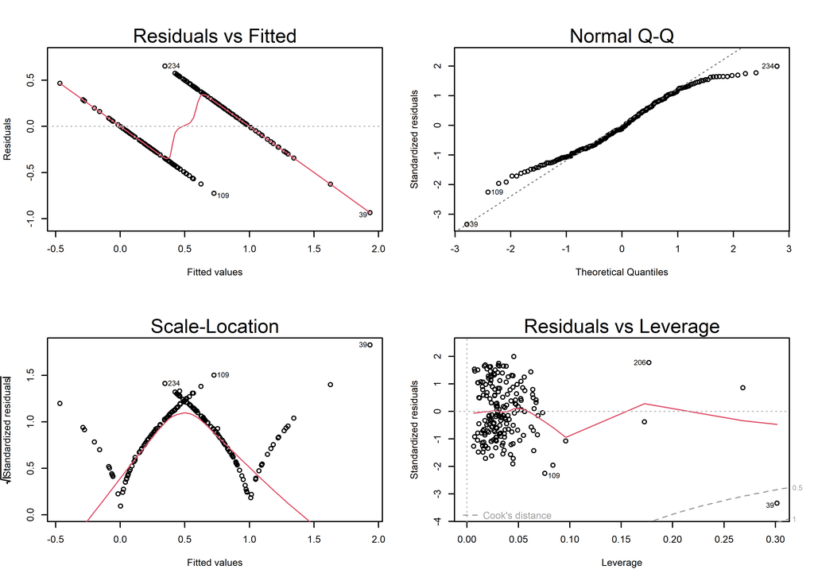

```r
plot(rawlm)
```

```r
par(mfrow=c(2,2),cex=0.5)
Delm <- lm(Overweight~.,BMI_Decorrelated_test[,c("Overweight",names(modelOverweight$coef)[-1])])
pander::pander(Delm,add.significance.stars=TRUE)
```

Fitting linear model: Overweight ~ .

|  | Estimate | Std. Error | t value | Pr(>\|t\|) |  |
| --- | --- | --- | --- | --- | --- |
| **(Intercept)** | -3.4446 | 0.87566 | -3.93 | 2.23e-04 | * * * |
| **BodyFat** | 0.0395 | 0.00496 | 7.95 | 6.56e-11 | * * * |
| **La_Chest** | 0.0354 | 0.01054 | 3.36 | 1.39e-03 | * * |
| **La_Hip** | 0.0357 | 0.00961 | 3.71 | 4.55e-04 | * * * |

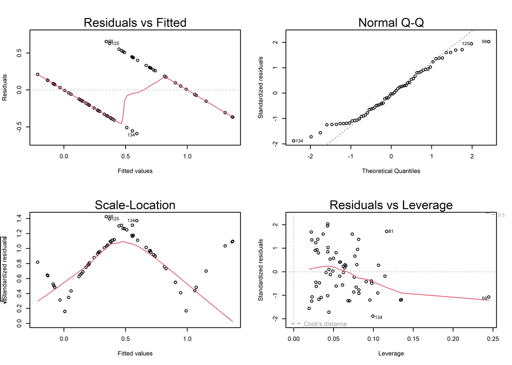

```r
plot(Delm)
```